# Exercise Day 2—Answer Key

Lugano Summer School—Machine Learning

Author

Marco R. Steenbergen

Published

August 14, 2024

# Objective and Data

The goal of this exercise is to compare the flexible CART algorithm with the much less flexible regression model. We do this using the Boston Housing data of Harrison and Rubinfeld (1978), specifically `BostonHousing2`. Just to remind you, the data can loaded from the `mlbench` package. The help file for that package explains the different variables.

# Answers

## Question 1

> Run a regression analysis. For this analysis, we do not worry about transforming the data. What is the R-squared for the test data?

First, we read in the data and generate training and test sets. These will be used for both the regression and CART algorithms. *Hint:* click on the arrow below to unfold the code.

```r
library(mlbench)
library(tidyverse)
library(tidymodels)
tidymodels_prefer()
data("BostonHousing2")
work_df <- BostonHousing2 %>%
  select(-c(town, medv, lon, lat))
set.seed(10)
split <- initial_split(work_df, prop = 0.8)
train <- training(split)
test <- testing(split)
```

Next, we write a recipe where we change the role of `tract` to that of an identifier.

```r
housing_rec <- recipe(cmedv ~ ., data = train) %>%
  update_role(tract, new_role = "id variable")
```

We now specify the regression model and build the work flow.

```r
housing_reg <- linear_reg() %>%
  set_mode("regression") %>%
  set_engine("lm")
reg_flow <- workflow() %>%
  add_recipe(housing_rec) %>%
  add_model(housing_reg)
```

The next step is to fit the model to training data.

```r
reg_fit <- fit(reg_flow, train)
tidy(reg_fit)
```

```
# A tibble: 14 × 5
   term         estimate std.error statistic  p.value
   <chr>           <dbl>     <dbl>     <dbl>    <dbl>
 1 (Intercept)  38.0       5.72        6.65  1.00e-10
 2 crim         -0.0734    0.0518     -1.42  1.57e- 1
 3 zn            0.0386    0.0151      2.55  1.11e- 2
 4 indus         0.0175    0.0723      0.241 8.09e- 1
 5 chas1         2.77      1.06        2.62  9.21e- 3
 6 nox         -18.4       4.31       -4.26  2.57e- 5
 7 rm            3.50      0.468       7.49  4.73e-13
 8 age           0.00478   0.0147      0.326 7.45e- 1
 9 dis          -1.46      0.219      -6.63  1.10e-10
10 rad           0.261     0.0759      3.44  6.35e- 4
11 tax          -0.0118    0.00428    -2.76  6.07e- 3
12 ptratio      -0.932     0.150      -6.22  1.25e- 9
13 b             0.0106    0.00325     3.27  1.16e- 3
14 lstat        -0.548     0.0574     -9.54  1.55e-19
```

The predictive performance in the test data is as follows:

```r
test1 <- test
reg_fit %>%
  predict(test1) %>%
  bind_cols(test1) %>%
  metrics(truth = cmedv, estimate = .pred)
```

```
# A tibble: 3 × 3
  .metric .estimator .estimate
  <chr>   <chr>          <dbl>
1 rmse    standard       4.30
2 rsq     standard       0.806
3 mae     standard       3.07
```

## Question 2

> Train a CART and plot the decision tree.

For the CART, we start by generating a new workflow and by tuning the hyper-parameters.

```r
housing_cart <- decision_tree(tree_depth = tune(),
                           min_n = tune(),
                           cost_complexity = tune()) %>%
  set_mode("regression") %>%
  set_engine("rpart")
initial_flow <- workflow() %>%
  add_recipe(housing_rec) %>%
  add_model(housing_cart)
set.seed(20)
housing_folds <- vfold_cv(train, v = 10)
cart_pars <- extract_parameter_set_dials(housing_cart)
set.seed(30)
cart_grid <- grid_latin_hypercube(cart_pars,
                                  size = 100,
                                  variogram_range = 0.6)
doParallel::registerDoParallel()
cart_tune <- initial_flow %>%
  tune_grid(housing_folds,
            grid = cart_grid,
            metrics = metric_set(rsq))
cart_opt <- select_best(cart_tune)
cart_opt
```

```
# A tibble: 1 × 4
  cost_complexity tree_depth min_n .config
            <dbl>      <int> <int> <chr>
1         0.00153         10     7 Preprocessor1_Model049
```

We now finalize the fit and render the tree.

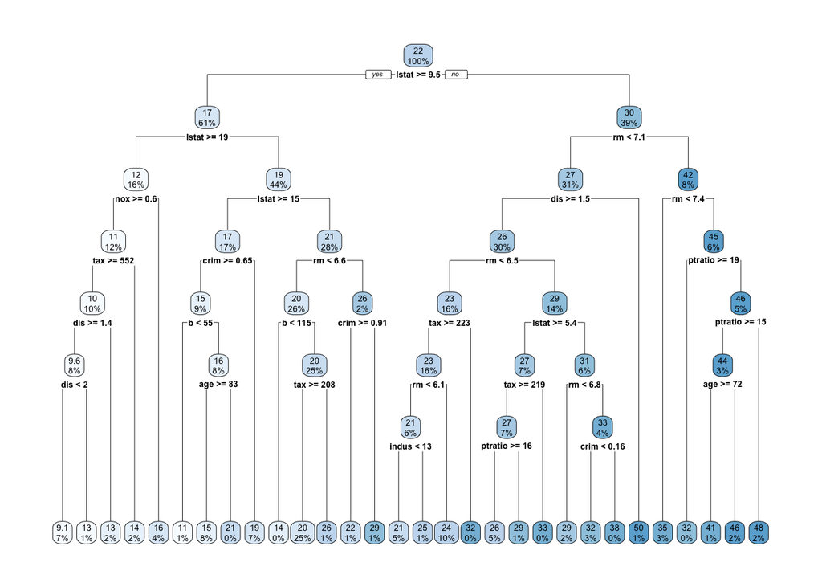

```r
library(rpart.plot)
cart_updated <- finalize_model(housing_cart,
                               cart_opt)
workflow_new <- initial_flow %>%
  update_model(cart_updated)
cart_fit_final <- workflow_new %>%
  fit(data = train)
tree <- extract_fit_engine(cart_fit_final)
rpart.plot(tree, roundint = FALSE)
```

## Question 3

> How well does the tree predict the test data? How much better is the predictive performance compared to the regression?

```r
test2 <- test
cart_fit_final %>%
  predict(test2) %>%
  bind_cols(test2) %>%
  metrics(truth = cmedv, estimate = .pred)
```

```
# A tibble: 3 × 3
  .metric .estimator .estimate
  <chr>   <chr>          <dbl>
1 rmse    standard       3.25
2 rsq     standard       0.891
3 mae     standard       2.52
```

We improved $R^2$ by around 0.08 points.

## References

Harrison, David, and Daniel L Rubinfeld. 1978. “Hedonic Housing Prices and the Demand for Clean Air.” *Journal of Environmental Economics and Management* 5 (1): 81–102. https://doi.org/10.1016/0095-0696(78)90006-2.